# Examen Módulo III – Análisis de Datos Multivariantes I Año 2020

Yulia Frenkel

05 03 2020

## Ejercicio 1

Lea los datos del fichero oecd, el cual tiene los siguientes campos: • country • GDP (PIB) • debt.gdp.ratio (Ratio de deuda sobre el PIB) • debt (deuda) • share.of.debt (porcentaje de deuda sobre el total de la deuda de la OCDE) Muestre los primeros y los últimos registros y realice un sumario de estadísticas. Represente gráficamente la relación entre la ratio de deuda sobre el PIB (X) y el porcentaje de deuda sobre el total de la deuda de la OCDE (Y). Ponga título al gráfico y a los ejes X e Y

```r
#install.packages("car")
library(car)
setwd("C:")
getwd()
```

```
## [1] "C:/Users/rsm_000/Desktop"
```

```r
oecd<- read.table("oecd.txt", sep = ",", header = TRUE)
head(oecd,n=1L)
```

```
##         country      gdp debt.gdp.ratio     debt share.of.debt
## 1 United States 19485.39           82.3 16036.48         35.25
```

```r
tail(oecd, n=1L)
```

```
##    country   gdp debt.gdp.ratio debt share.of.debt
## 36 Estonia 25.92            9.3 2.41          0.01
```

```r
summary(oecd)
```

```
##            country        gdp           debt.gdp.ratio        debt
##  Australia     : 1   Min.   :   24.48   Min.   :  9.30   Min.   :    2.41
##  Austria       : 1   1st Qu.:  200.29   1st Qu.: 38.42   1st Qu.:   74.27
##  Belgium       : 1   Median :  408.15   Median : 51.55   Median :  236.72
##  Canada        : 1   Mean   : 1385.63   Mean   : 67.16   Mean   : 1263.86
##  Chile         : 1   3rd Qu.: 1337.90   3rd Qu.: 83.47   3rd Qu.:  668.38
##  Czech Republic: 1   Max.   :19485.39   Max.   :223.80   Max.   :16036.48
##  (Other)       :30
##  share.of.debt
##  Min.   : 0.010
##  1st Qu.: 0.165
##  Median : 0.520
##  Mean   : 2.777
##  3rd Qu.: 1.470
##  Max.   :35.250
##
```

```r
str(oecd)
```

```
## 'data.frame':    36 obs. of  5 variables:
##  $ country       : Factor w/ 36 levels "Australia","Austria",..: 36 18 17 10 11 35 4 31 30 1 ...
##  $ gdp           : num  19485 4872 1944 2582 3693 ...
##  $ debt.gdp.ratio: num  82.3 223.8 131.2 98.5 64.1 ...
##  $ debt          : num  16036 10904 2550 2544 2367 ...
##  $ share.of.debt : num  35.25 23.97 5.61 5.59 5.2 ...
```

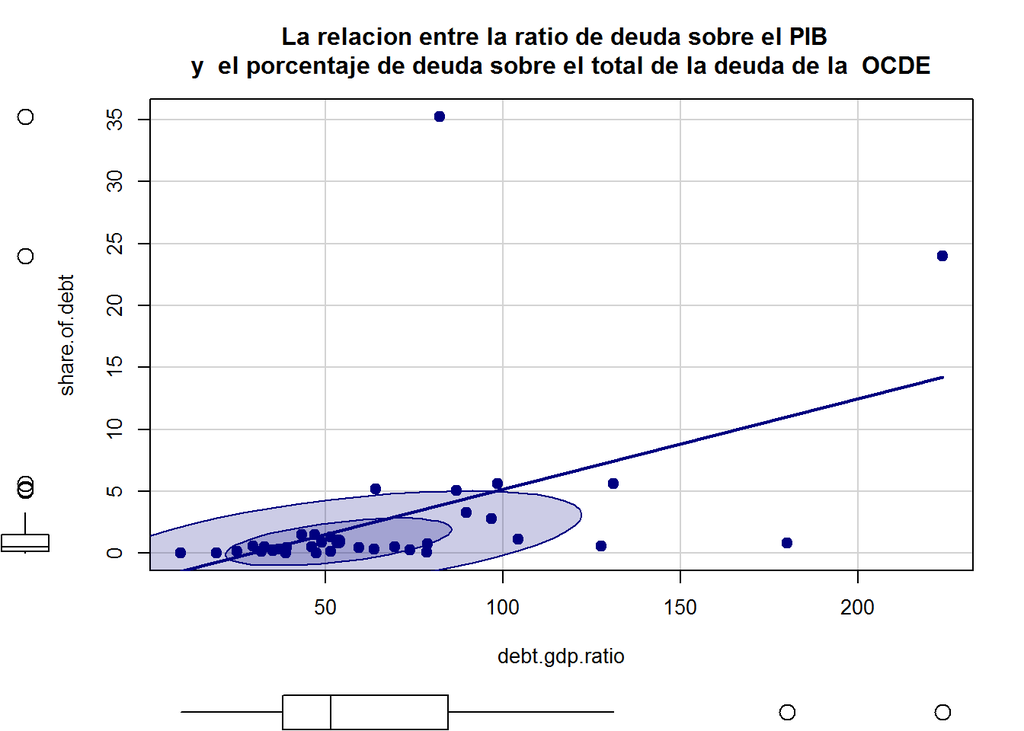

```r
scatterplot(share.of.debt ~oecd$debt.gdp.ratio, data=oecd, main = "La relación entre la ratio de deuda sobre el PIB  \ny  el porcentaje de deuda sobre el total de la deuda de la  OCDE", xlab = "debt.gdp.ratio", ylab = "share.of.debt",pch = 20, col = "navy",cex = 1.75, smooth=F, ellipse=T)
```

## Ejercicio 2

Realice una regresión lineal simple por Mínimos Cuadrados Ordinarios. Presente sumario de resultados y estadísticas de los residuos. Responda: ¿son significativos los coeficientes?, ¿son normales los residuos?, ¿hay problemas de valores extremos?, ¿hay problemas de heterocedasticidad?, ¿la transformación logarítmica de los datos resuelve los problemas que ha encontrado?.

```r
library(lmtest)
library(olsrr)
```

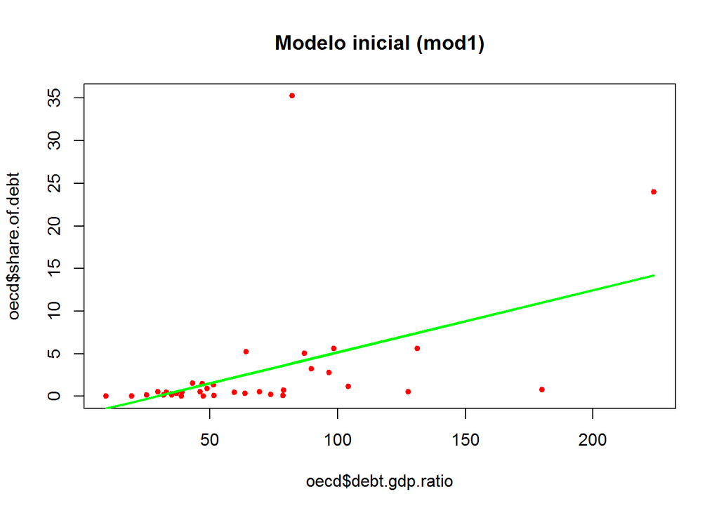

```r
library(nortest)
library(ggplot2)
mod1 <-lm(share.of.debt ~ debt.gdp.ratio, data=oecd)
plot(x = oecd$debt.gdp.ratio, y =oecd$share.of.debt, pch = 20, col = "red")
title("Modelo inicial (mod1)")
lines(x=oecd$debt.gdp.ratio, y=mod1$fitted.values, col = "green", lwd = 2)
```

```r
# Resumen del modelo
summary(mod1)
```

```
##
## Call:
## lm(formula = share.of.debt ~ debt.gdp.ratio, data = oecd)
##
## Residuals:
##      Min       1Q   Median       3Q      Max
## -10.2064  -1.9136  -0.4442   0.4401  31.3685
##
## Coefficients:
##                Estimate Std. Error t value Pr(>|t|)
## (Intercept)    -2.12030    1.89994  -1.116  0.27226
## debt.gdp.ratio  0.07293    0.02370   3.077  0.00411 **
## ---
## Signif. codes:  0 '***' 0.001 '**' 0.01 '*' 0.05 '.' 0.1 ' ' 1
##
## Residual standard error: 6.225 on 34 degrees of freedom
## Multiple R-squared:  0.2178, Adjusted R-squared:  0.1948
## F-statistic: 9.469 on 1 and 34 DF,  p-value: 0.004112
```

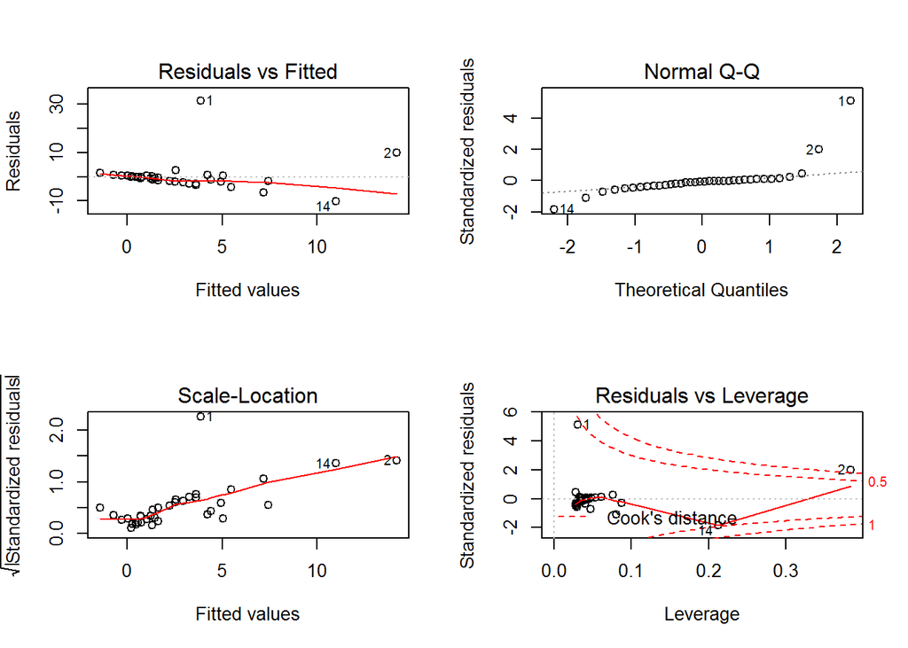

```r
# Análisis de los residuos
# Gráficos
layout(matrix(c(1:4), nrow = 2, byrow = T))
plot(mod1)
```

```r
# Test de normalidad
shapiro.test(mod1$residuals)#  p-value < 0.05 rechezamos la hipotesis nula de la distribucion normal de residuos
```

```
##
##  Shapiro-Wilk normality test
##
## data:  mod1$residuals
## W = 0.55489, p-value = 2.812e-09
```

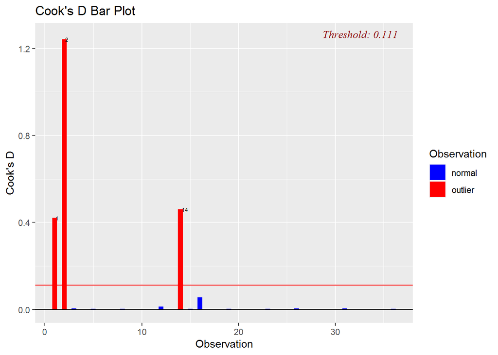

```r
ols_plot_cooksd_bar(mod1) # tres outliers
```

```r
analiz <-fortify(mod1)
head(analiz,n=15L)
```

```
##    share.of.debt debt.gdp.ratio       .hat   .sigma      .cooksd   .fitted
## 1          35.25           82.3 0.03109976 3.024666 4.206242e-01  3.881521
## 2          23.97          223.8 0.38341593 5.935712 1.242031e+00 14.200571
## 3           5.61          131.2 0.08722023 6.309612 4.561421e-03  7.447610
## 4           5.59           98.5 0.04201340 6.317794 1.641054e-04  5.062925
## 5           5.20           64.1 0.02791360 6.301198 2.668131e-03  2.554265
## 6           5.03           87.0 0.03348262 6.316879 3.002504e-04  4.224274
## 7           3.25           89.7 0.03514111 6.315080 6.680968e-04  4.421174
## 8           2.79           96.7 0.04042507 6.307017 2.598373e-03  4.931657
## 9           1.50           43.3 0.03603037 6.317957 1.070680e-04  1.037401
## 10          1.46           47.1 0.03361114 6.318437 9.828611e-06  1.314520
## 11          1.31           51.5 0.03133290 6.318228 4.562290e-05  1.635395
## 12          1.13          104.3 0.04777027 6.270527 1.289846e-02  5.485896
## 13          0.89           49.0 0.03255851 6.317704 1.423193e-04  1.453080
## 14          0.80          180.0 0.21233318 5.992968 4.600307e-01 11.006406
```

[output cut: 17 more lines]

```r
# Test de heterocedasticidad
bptest (mod1, data=oecd)
```

```
##
##  studentized Breusch-Pagan test
##
## data:  mod1
## BP = 1.1379, df = 1, p-value = 0.2861
```

```r
#p>0.05 por eso es imposible rechazar la hipotesis nula de homocedasticidad de los residuos, por tanto son homocedastico.
# Modelo 2 con logaritmos
mod2 <- lm(log(share.of.debt) ~ log(debt.gdp.ratio), data=oecd)
# Resumen del modelo
summary(mod2)
```

```
##
## Call:
## lm(formula = log(share.of.debt) ~ log(debt.gdp.ratio), data = oecd)
##
## Residuals:
##     Min      1Q  Median      3Q     Max
## -2.6126 -0.6997  0.2584  0.9479  3.3807
##
## Coefficients:
##                     Estimate Std. Error t value Pr(>|t|)
## (Intercept)          -8.9138     1.5044  -5.925 1.08e-06 ***
## log(debt.gdp.ratio)   2.0623     0.3698   5.577 3.05e-06 ***
## ---
## Signif. codes:  0 '***' 0.001 '**' 0.01 '*' 0.05 '.' 0.1 ' ' 1
##
## Residual standard error: 1.376 on 34 degrees of freedom
## Multiple R-squared:  0.4778, Adjusted R-squared:  0.4624
## F-statistic: 31.11 on 1 and 34 DF,  p-value: 3.053e-06
```

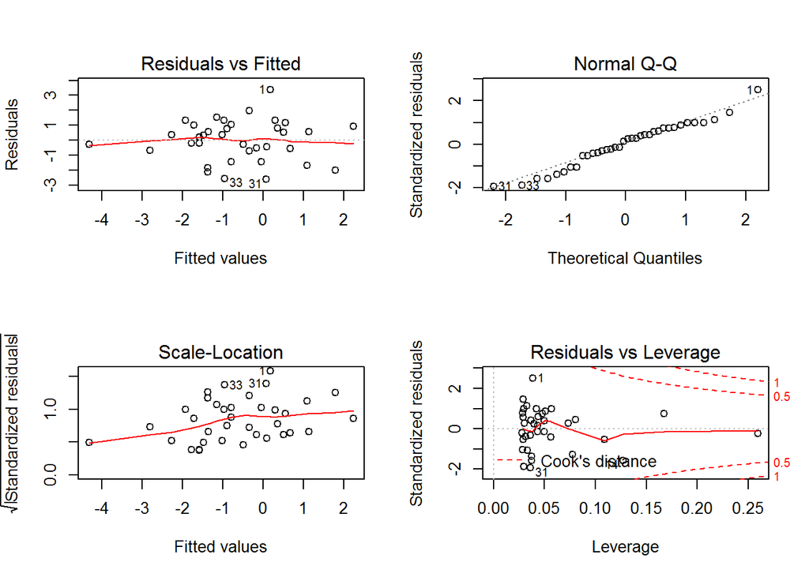

```r
# Análisis de los residuos
# Gráficos
layout(matrix(c(1:4), nrow = 2, byrow = T))
plot(mod2)
```

```r
# Test de normalidad
shapiro.test(mod2$residuals) #  p-value >> 0.05  no rechezamos la hipotesis nula de la distribucion normal de residuos
```

```
##
##  Shapiro-Wilk normality test
##
## data:  mod2$residuals
## W = 0.97183, p-value = 0.4777
```

```r
# Test de heterocedasticidad
bptest (mod2, data=oecd)# p>0.05 por eso es imposible rechazar la hipotesis nula de homocedasticidad de los residuos, por tanto son homocedastico.
```

```
##
##  studentized Breusch-Pagan test
##
## data:  mod2
## BP = 1.541, df = 1, p-value = 0.2145
```

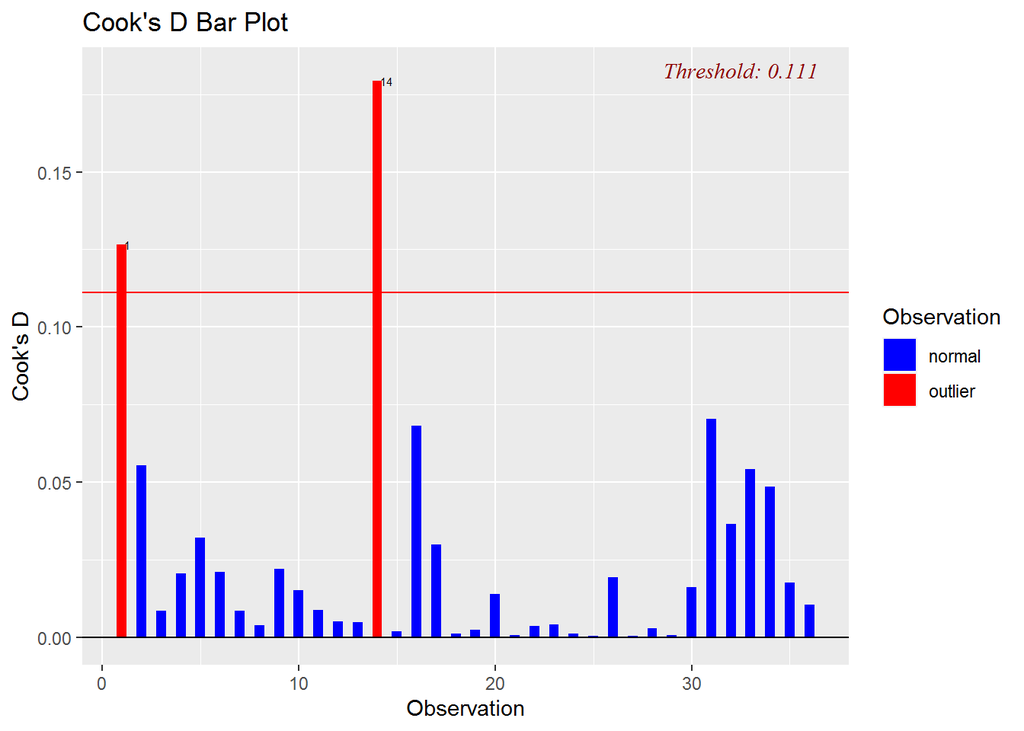

```r
ols_plot_cooksd_bar(mod2)
```

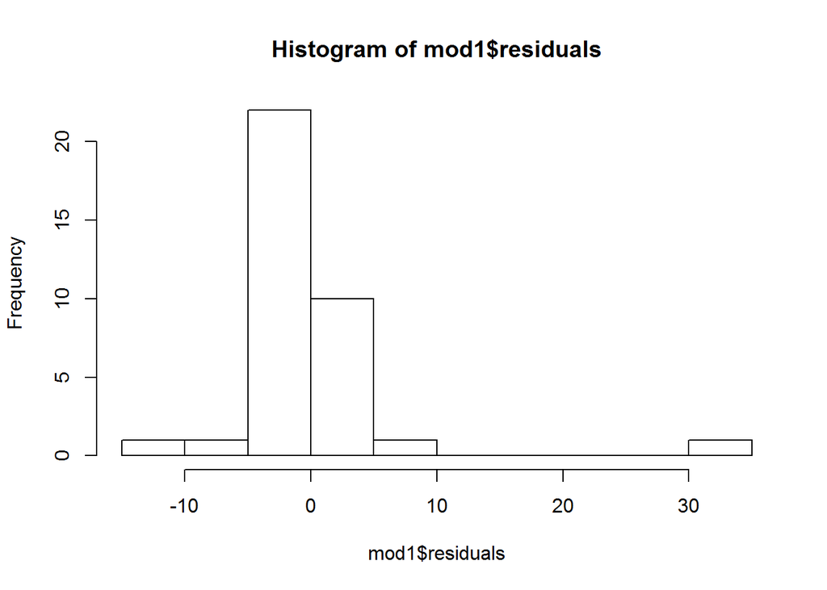

```r
hist(mod1$residuals)
```

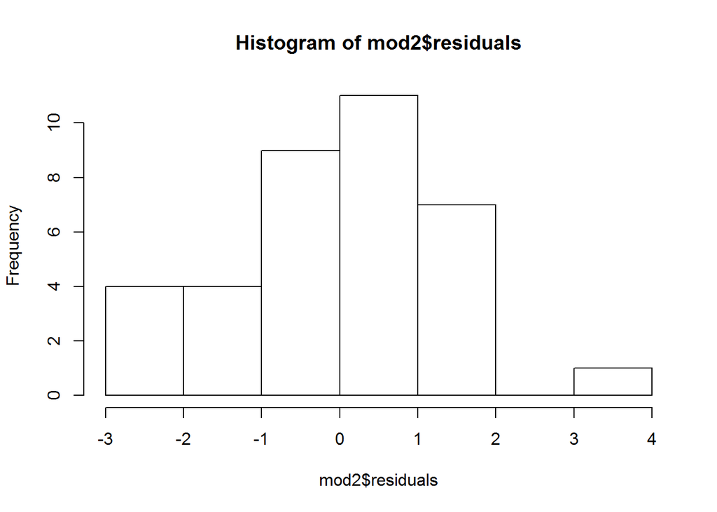

```r
hist(mod2$residuals)
```

```r
#En mod2 la distribucion de residuals se aserca a lo normal
```

Comentarios El modelo inicial tiene una baja capacidad explicativa (coeficiente de determinación muy bajo), solo es significativa la pendiente. La representación gráfica de los resultados de este modelo pone de manifiesto la inadecuación de esta forma funcional, siendo evidentes que la distribucion no es normal. Hay tres valores extremos. El modelo en logaritmos presenta una mayor capacidad explicativa (coeficiente de determinación mas alto), siendo estadísticamente significativos los dos parámetros, que el modelo inicial y se resolvo el problema con la normalidad de la distribucion, aunque quedan 2 outliers, pero su impacto al model es menor.

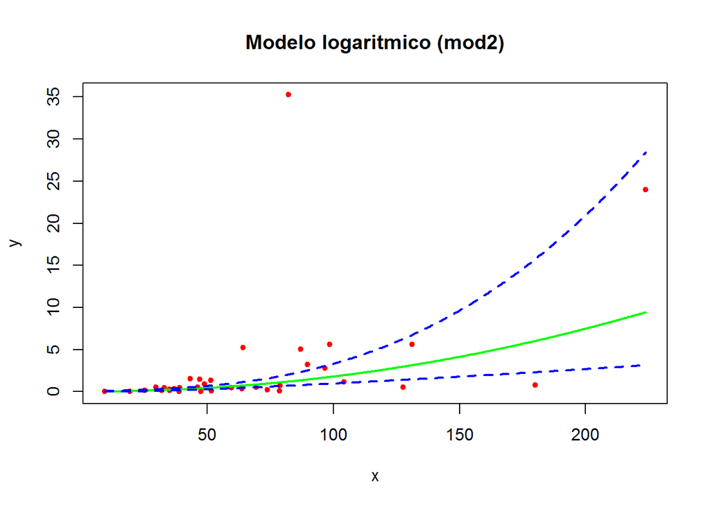

```r
#Valores predichos
#Una vez ajustado el modelo, generamos un conjunto de puntos nuevo para poder predecir nuevos valores regresados
x <- oecd$debt.gdp.ratio
y <- oecd$share.of.debt
rang <- range(x)
npuntos <- seq(from = rang[1], to = rang[2], by = 0.5)
npuntos <- data.frame(debt.gdp.ratio = npuntos)
npredic  <- predict(mod2, newdata = npuntos, se.fit = TRUE, level = 0.95)
intconf <- data.frame(
                  inferior = npredic$fit - 1.96*npredic$se.fit,
                  superior = npredic$fit + 1.96*npredic$se.fit)
#Y finalmente se dibujan los puntos originales con los puntos predichos y el intervalo de confianza.
plot(x = x, y = y, pch = 20, col = "red")
title("Modelo logaritmico (mod2)")
lines(x = npuntos$debt.gdp.ratio, exp(npredic$fit), col = "green", lwd = 2)
lines(x = npuntos$debt.gdp.ratio, exp(intconf$inferior), col = "blue",
      lwd = 2, lty = 2)
lines(x = npuntos$debt.gdp.ratio, exp(intconf$superior), col = "blue",
      lwd = 2, lty = 2)
```

## Ejercicio 3

Plantee una regresión lineal múltiple que explique porcentaje de deuda sobre el total de la deuda de la OCDE y el PIB utilizando una regresión polinómica de orden 2 y 3. Evalúe los resultados del modelo. Establezca un intervalo de confianza para los coeficientes con α=0.05 y α=0.10. Evalúe los resultados obtenidos en los dos modelos. Intente solucionar los problemas de los valores extremos utilizando variables dummies.

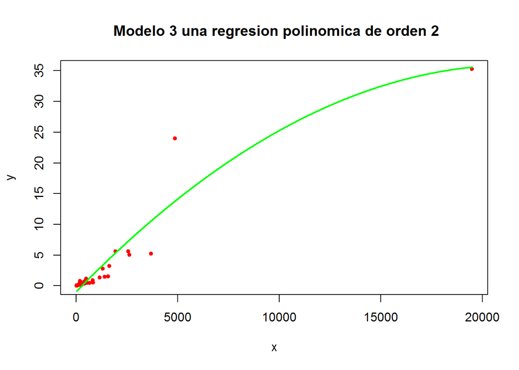

```r
# Modelo 3 una regresión polinómica de orden 2
mod3 <- lm(share.of.debt ~ poly(gdp,2), data = oecd)
x <- oecd$gdp
y <- oecd$share.of.debt
rang <- range(x)
npuntos1 <- seq(from = rang[1], to = rang[2], by = 0.5)
npuntos1 <- data.frame(gdp = npuntos1)
npredic1  <- predict(mod3, newdata = npuntos1, se.fit = TRUE, level = 0.95)
# Grafico
plot(x = x, y = y, pch = 20, col = "red")
title(" Modelo 3 una regresión polinómica de orden 2")
lines(x = npuntos1$gdp, npredic1$fit, col = "green", lwd = 2)
```

```r
# Resumen del modelo
summary(mod3)
```

```
##
## Call:
## lm(formula = share.of.debt ~ poly(gdp, 2), data = oecd)
##
## Residuals:
##     Min      1Q  Median      3Q     Max
## -5.3622 -0.8469  0.2374  0.7621 10.1795
##
## Coefficients:
##               Estimate Std. Error t value Pr(>|t|)
## (Intercept)     2.7775     0.3784   7.339    2e-08 ***
## poly(gdp, 2)1  38.0913     2.2707  16.775  < 2e-16 ***
## poly(gdp, 2)2  -7.9554     2.2707  -3.504  0.00134 **
## ---
## Signif. codes:  0 '***' 0.001 '**' 0.01 '*' 0.05 '.' 0.1 ' ' 1
##
## Residual standard error: 2.271 on 33 degrees of freedom
## Multiple R-squared:  0.899,  Adjusted R-squared:  0.8929
## F-statistic: 146.8 on 2 and 33 DF,  p-value: < 2.2e-16
```

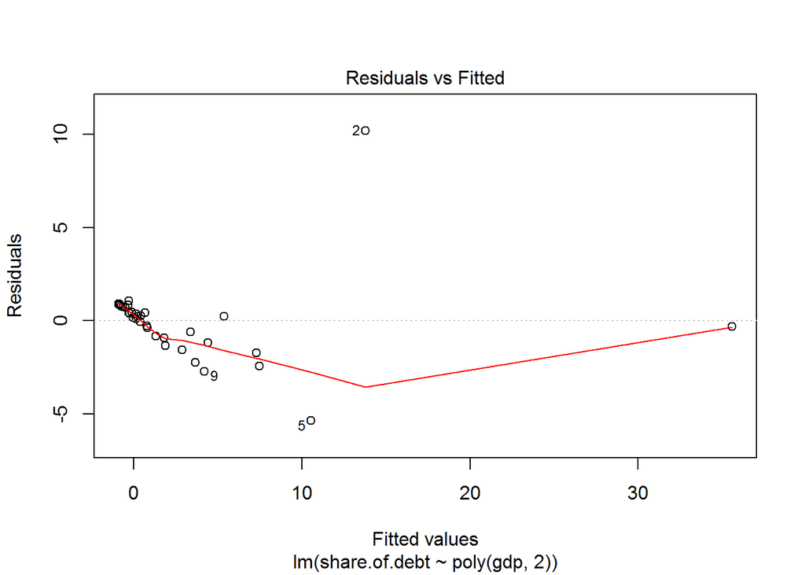

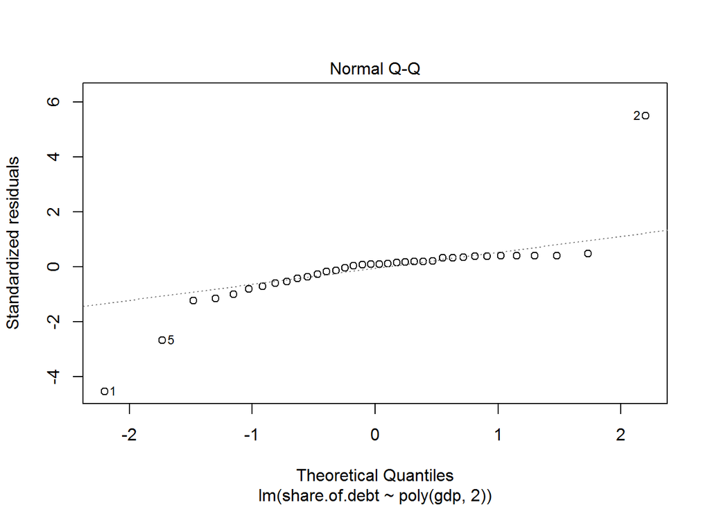

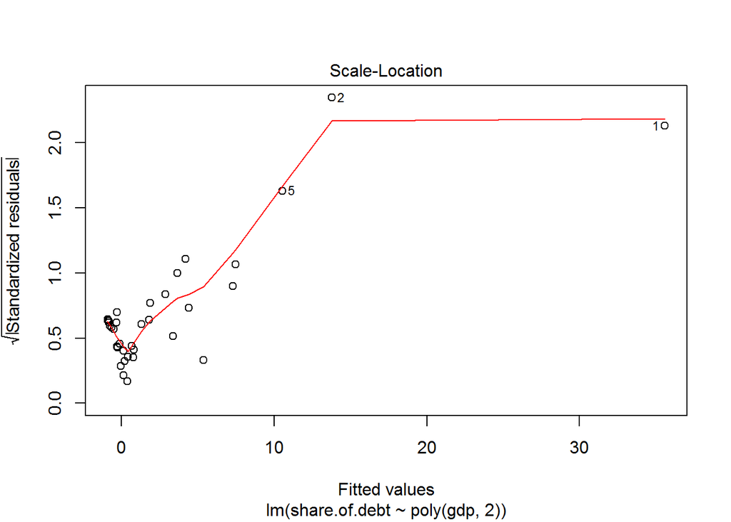

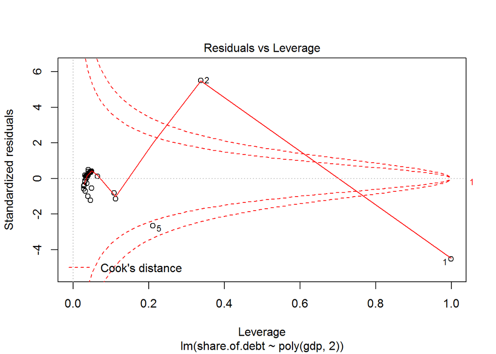

```r
# Análisis de los residuos
# Gráficos
plot(mod3)
```

```r
# Test de normalidad
shapiro.test(mod3$residuals)#  p-value < 0.05 rechezamos la hipotesis nula de la distribucion normal de residuos
```

```
##
##  Shapiro-Wilk normality test
##
## data:  mod3$residuals
## W = 0.69596, p-value = 2.446e-07
```

```r
# Test de heterocedasticidad
bptest (mod3, data=oecd)# p<0.05 por eso  rechazamos la hipotesis nula de homocedasticidad de los residuos, por tanto son heteroxedático.
```

```
##
##  studentized Breusch-Pagan test
##
## data:  mod3
## BP = 17.761, df = 2, p-value = 0.0001391
```

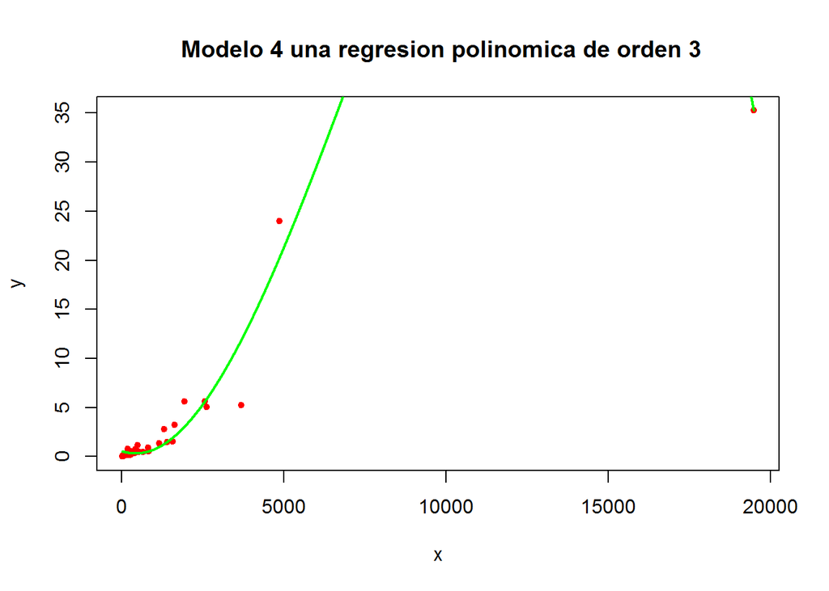

```r
# Modelo 4 una regresión polinómica de orden 3
mod4 <-lm(share.of.debt ~ poly(gdp,3), data = oecd)
npuntos2 <- seq(from = rang[1], to = rang[2], by = 0.5)
npuntos2 <- data.frame(gdp = npuntos2)
npredic2  <- predict(mod4, newdata = npuntos2, se.fit = TRUE, level = 0.95)
plot(x = x, y = y, pch = 20, col = "red")
title(" Modelo 4 una regresión polinómica de orden 3")
lines(x = npuntos2$gdp, npredic2$fit, col = "green", lwd = 2)
```

```r
# Resumen del modelo
summary (mod4)
```

```
##
## Call:
## lm(formula = share.of.debt ~ poly(gdp, 3), data = oecd)
##
## Residuals:
##     Min      1Q  Median      3Q     Max
## -6.6817 -0.3630 -0.0071  0.2374  3.6870
##
## Coefficients:
##               Estimate Std. Error t value Pr(>|t|)
## (Intercept)     2.7775     0.2505  11.089 1.71e-12 ***
## poly(gdp, 3)1  38.0913     1.5029  25.345  < 2e-16 ***
## poly(gdp, 3)2  -7.9554     1.5029  -5.293 8.46e-06 ***
## poly(gdp, 3)3  -9.8928     1.5029  -6.582 2.03e-07 ***
## ---
## Signif. codes:  0 '***' 0.001 '**' 0.01 '*' 0.05 '.' 0.1 ' ' 1
##
## Residual standard error: 1.503 on 32 degrees of freedom
## Multiple R-squared:  0.9571, Adjusted R-squared:  0.9531
## F-statistic: 237.9 on 3 and 32 DF,  p-value: < 2.2e-16
```

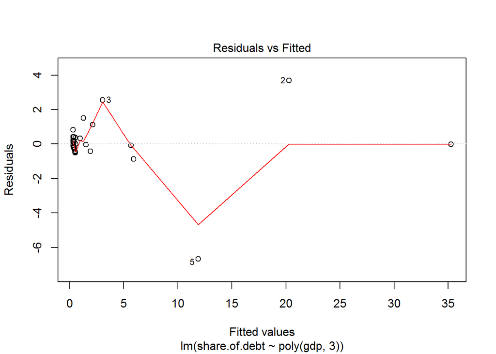

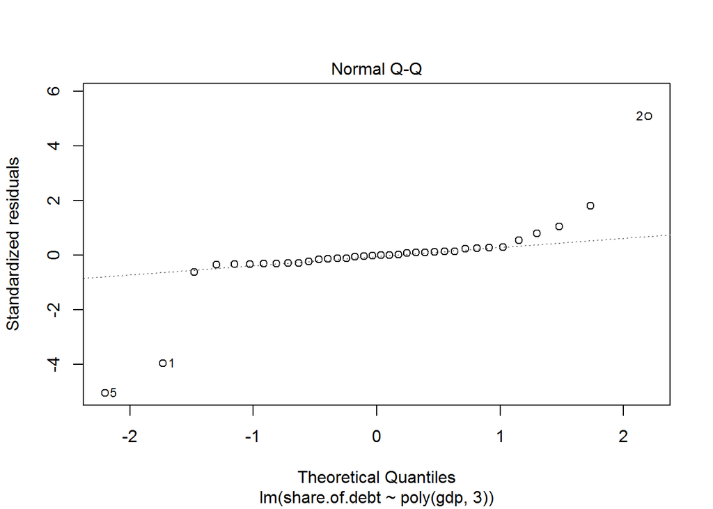

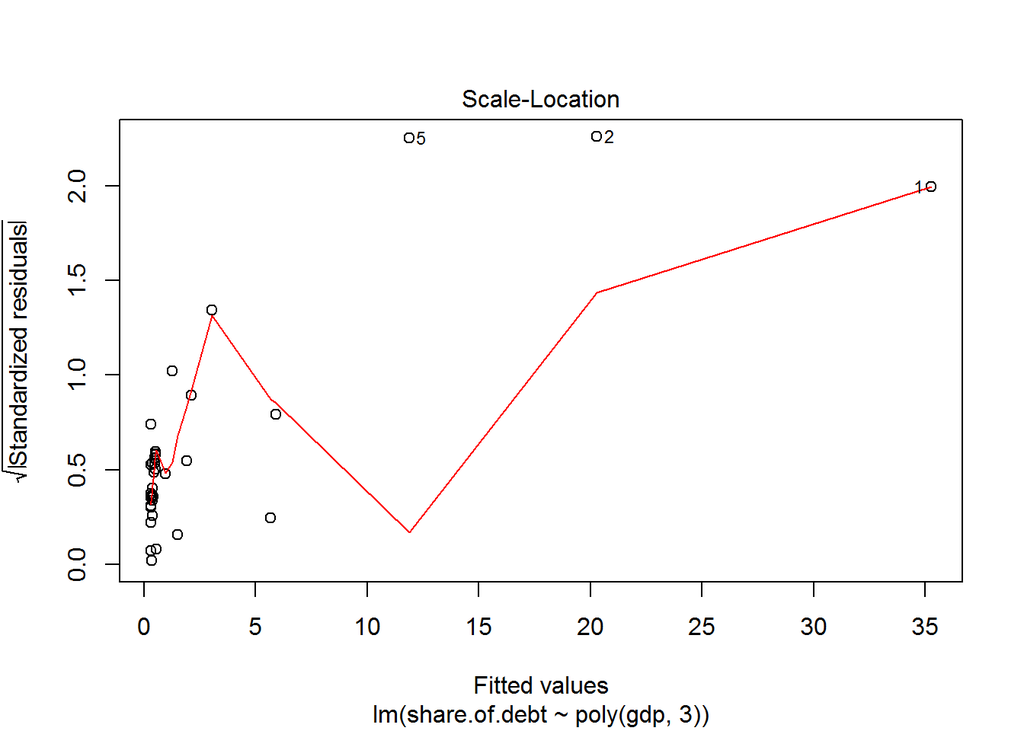

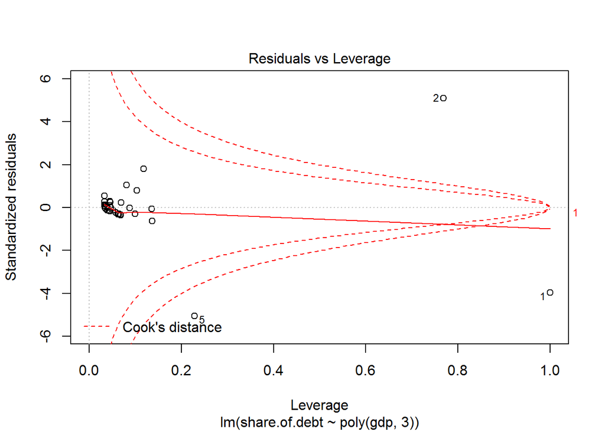

```r
# Análisis de los residuos
# Gráficos
plot(mod4)
```

```r
# Test de normalidad
shapiro.test(mod4$residuals)#  p-value < 0.05 rechezamos la hipotesis nula de la distribucion normal de residuos
```

```
##
##  Shapiro-Wilk normality test
##
## data:  mod4$residuals
## W = 0.6401, p-value = 3.658e-08
```

```r
# Test de heterocedasticidad
bptest (mod4, data=oecd)# p<0.05 por eso  rechazamos la hipotesis nula de homocedasticidad de los residuos, por tanto son heteroxedático.
```

```
##
##  studentized Breusch-Pagan test
##
## data:  mod4
## BP = 16.508, df = 3, p-value = 0.000892
```

```r
# Intervalos de confianza: 95%  y 90% para mod3 y  mod4.
confint(mod3)
```

```
##                   2.5 %    97.5 %
## (Intercept)     2.00755  3.547450
## poly(gdp, 2)1  33.47156 42.710957
## poly(gdp, 2)2 -12.57511 -3.335707
```

```r
confint(mod4)
```

```
##                    2.5 %    97.5 %
## (Intercept)     2.267285  3.287715
## poly(gdp, 3)1  35.029966 41.152549
## poly(gdp, 3)2 -11.016698 -4.894115
## poly(gdp, 3)3 -12.954075 -6.831492
```

```r
confint (mod3, level=0.9)
```

```
##                      5 %      95 %
## (Intercept)     2.137037  3.417963
## poly(gdp, 2)1  34.248477 41.934038
## poly(gdp, 2)2 -11.798187 -4.112626
```

```r
confint(mod4, level = 0.9)
```

```
##                      5 %      95 %
## (Intercept)     2.353211  3.201789
## poly(gdp, 3)1  35.545525 40.636990
## poly(gdp, 3)2 -10.501139 -5.409674
## poly(gdp, 3)3 -12.438516 -7.347051
```

```r
# creamos un variable dummy
oecd$outlier <- ifelse(abs(oecd$gdp) >= 2 * sd(oecd$gdp), 1, 0)
oecd$outlier <- as.factor(oecd$outlier)
# Modelo 5 polinomica  con  un variable dummy
mod5 <- lm(share.of.debt ~ poly(gdp,3) + outlier, data = oecd)
# Resumen del modelo
summary(mod5)
```

```
##
## Call:
## lm(formula = share.of.debt ~ poly(gdp, 3) + outlier, data = oecd)
##
## Residuals:
##     Min      1Q  Median      3Q     Max
## -3.8441 -0.4892 -0.0183  0.3905  2.8811
##
## Coefficients:
##               Estimate Std. Error t value Pr(>|t|)
## (Intercept)      76.81      13.49   5.694 2.94e-06 ***
## poly(gdp, 3)1  2515.13     451.31   5.573 4.15e-06 ***
## poly(gdp, 3)2   865.89     159.21   5.439 6.11e-06 ***
## poly(gdp, 3)3    72.89      15.12   4.820 3.59e-05 ***
## outlier1      -2665.25     485.59  -5.489 5.29e-06 ***
## ---
## Signif. codes:  0 '***' 0.001 '**' 0.01 '*' 0.05 '.' 0.1 ' ' 1
##
## Residual standard error: 1.087 on 31 degrees of freedom
## Multiple R-squared:  0.9782, Adjusted R-squared:  0.9754
## F-statistic: 348.4 on 4 and 31 DF,  p-value: < 2.2e-16
```

```r
# Test de normalidad
shapiro.test(mod5$residuals)
```

```
##
##  Shapiro-Wilk normality test
##
## data:  mod5$residuals
## W = 0.87082, p-value = 0.0005961
```

```r
# Test de heterocedasticidad
bptest (mod5, data=oecd)
```

```
##
##  studentized Breusch-Pagan test
##
## data:  mod5
## BP = 20.966, df = 4, p-value = 0.0003216
```

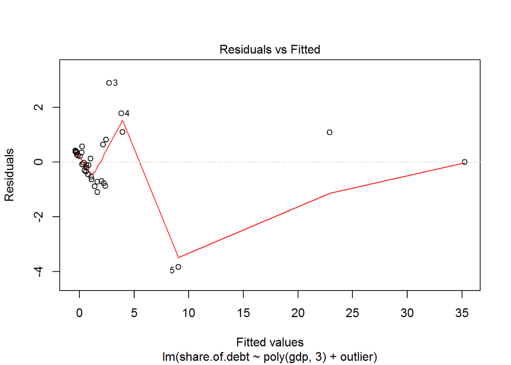

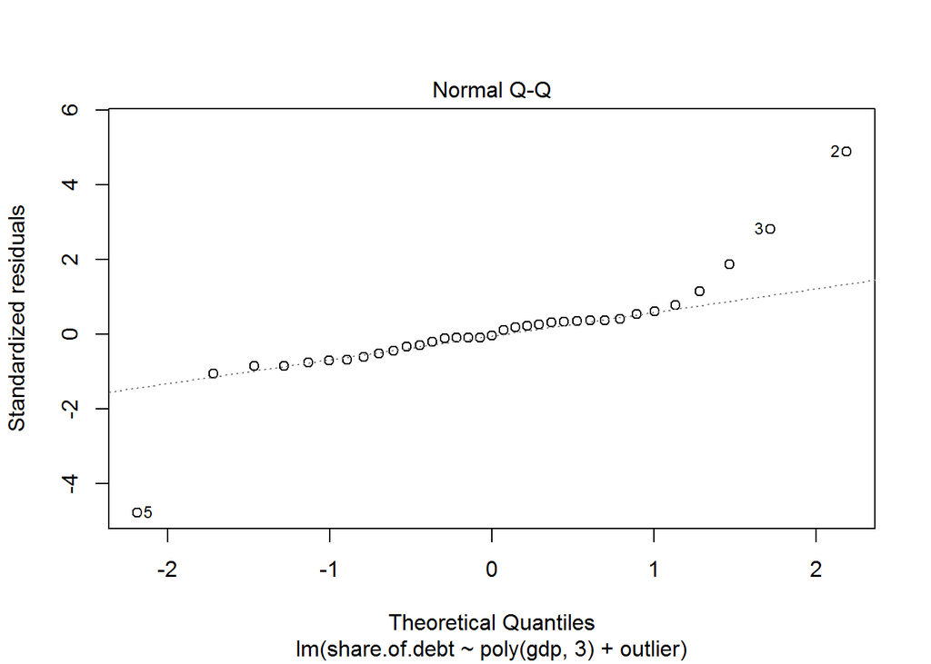

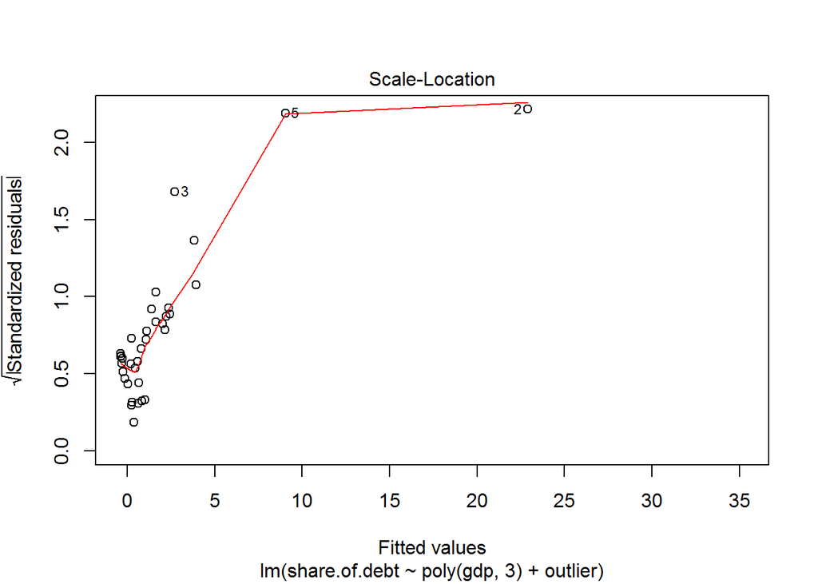

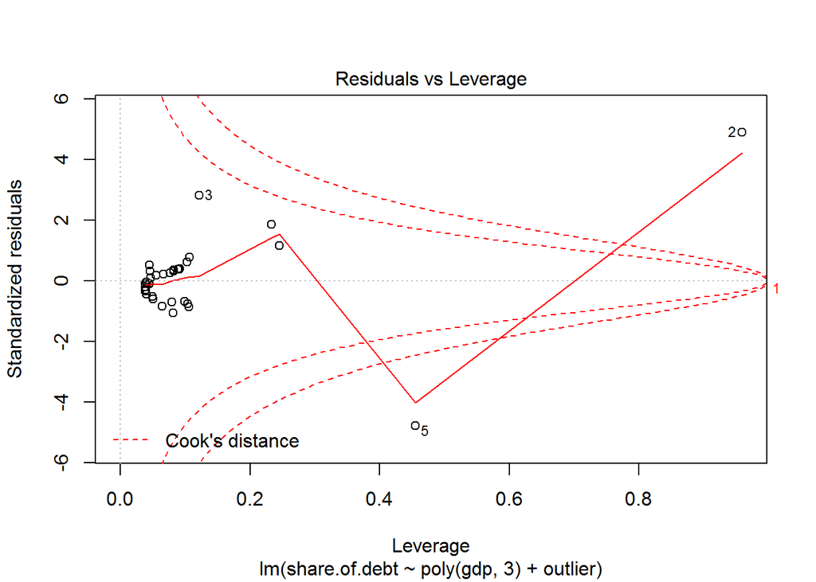

```r
# Análisis de los residuos
# Gráficos
plot(mod5)
```

```r
# creamos  dummy para US y Japan
oecd$jap <- ifelse(oecd$country == 'Japan', 1, 0)
oecd$us <- ifelse(oecd$country == "United States", 1, 0)
mod5.japus <- lm(share.of.debt ~ poly(gdp,3) + jap + us, data = oecd)
# Resumen del modelo
summary(mod5.japus)
```

```
##
## Call:
## lm(formula = share.of.debt ~ poly(gdp, 3) + jap + us, data = oecd)
##
## Residuals:
##      Min       1Q   Median       3Q      Max
## -1.37051 -0.19397 -0.01666  0.17942  1.69765
##
## Coefficients:
##               Estimate Std. Error t value Pr(>|t|)
## (Intercept)     -65.89      15.47  -4.260 0.000186 ***
## poly(gdp, 3)1 -2239.66     515.77  -4.342 0.000148 ***
## poly(gdp, 3)2  -796.01     180.57  -4.408 0.000123 ***
## poly(gdp, 3)3   -68.64      15.71  -4.368 0.000138 ***
## jap              26.23       2.58  10.168  3.1e-11 ***
## us             2445.76     554.51   4.411 0.000122 ***
## ---
## Signif. codes:  0 '***' 0.001 '**' 0.01 '*' 0.05 '.' 0.1 ' ' 1
##
## Residual standard error: 0.5242 on 30 degrees of freedom
## Multiple R-squared:  0.9951, Adjusted R-squared:  0.9943
## F-statistic:  1220 on 5 and 30 DF,  p-value: < 2.2e-16
```

```r
# Test de normalidad
shapiro.test(mod5.japus$residuals)
```

```
##
##  Shapiro-Wilk normality test
##
## data:  mod5.japus$residuals
## W = 0.88123, p-value = 0.001089
```

```r
# Test de heterocedasticidad
bptest (mod5.japus, data=oecd)
```

```
##
##  studentized Breusch-Pagan test
##
## data:  mod5.japus
## BP = 11.428, df = 5, p-value = 0.04353
```

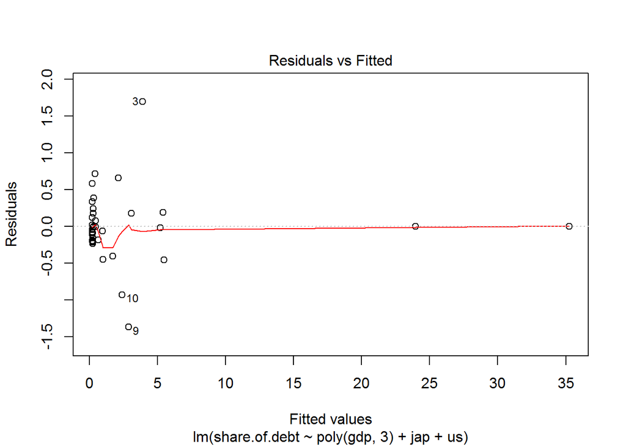

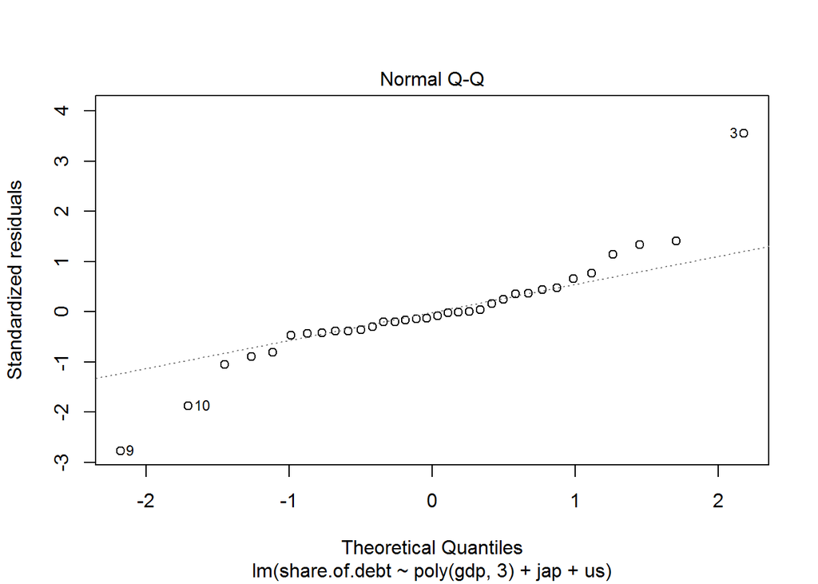

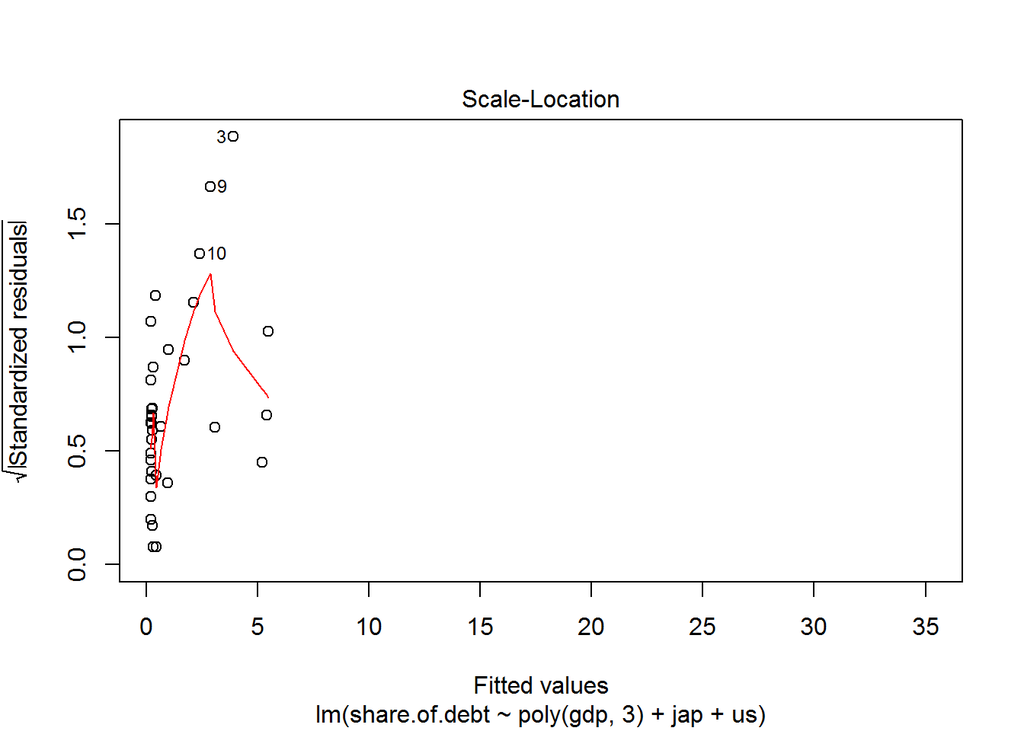

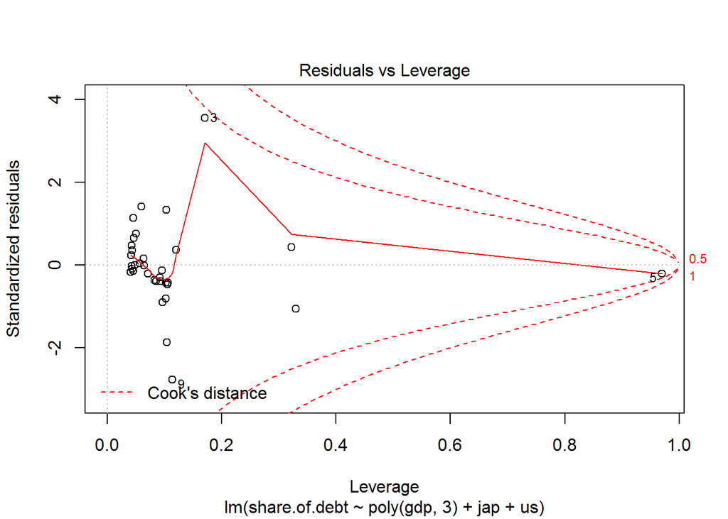

```r
# Análisis de los residuos
# Gráficos
plot(mod5.japus)
```

Comentarios En los modelos polinomiales obtenidos, vemos un aumento en el coeficiente de determinación, todos coefficientes son significativas, pero al mismo tiempo, la presencia de heteroxedaticidad y problema con no normalidad se deduce de los gráficos.La introducción de una variable dummy y dos variable dummy no resuelve el problema del heteroxedatismo y con normalidad tampoco.

## Ejercicio 4

Entre los modelos analizados en el curso, ¿cuál cree que es el más adecuado para resolver los problemas que ha encontrado en la mejor relación lineal entre el porcentaje de deuda sobre el total de la deuda de la OCDE y la tasa de deuda sobre el PIB?. Realice el ejercicio con el modelo que considere el más idóneo. Evalúe la normalidad de los residuos. Presente un gráfico con los porcentajes de deuda observados, los porcentajes estimados, y las bandas de confianza para los valores estimados con una α=0.05 y realice la predicción que daría el modelo para un país que lograra una tasa de deuda sobre el PIB del 25%.

```r
library(MASS)
#La regresión robusta
# Estimador Huber
mod6.esth <- rlm(share.of.debt ~ debt.gdp.ratio, data = oecd, psi = psi.huber)
summary(mod6.esth)
```

```
##
## Call: rlm(formula = share.of.debt ~ debt.gdp.ratio, data = oecd, psi = psi.huber)
## Residuals:
##      Min       1Q   Median       3Q      Max
## -5.24768 -0.78413  0.02294  0.73457 33.10397
##
## Coefficients:
##                Value   Std. Error t value
## (Intercept)    -1.1406  0.4435    -2.5720
## debt.gdp.ratio  0.0399  0.0055     7.2191
##
## Residual standard error: 1.153 on 34 degrees of freedom
```

```r
# Estimador bisquare
mod6.bisq <- rlm(share.of.debt ~ debt.gdp.ratio, data = oecd, psi = psi.bisquare)
summary(mod6.bisq)
```

```
##
## Call: rlm(formula = share.of.debt ~ debt.gdp.ratio, data = oecd, psi = psi.bisquare)
## Residuals:
##     Min      1Q  Median      3Q     Max
## -0.4400 -0.1775  0.0665  1.0853 34.7146
##
## Coefficients:
##                Value  Std. Error t value
## (Intercept)    0.1923 0.1340     1.4352
## debt.gdp.ratio 0.0042 0.0017     2.4939
##
## Residual standard error: 0.4219 on 34 degrees of freedom
```

```r
# Estadístico AIC para los quatro modelos
  AIC(mod2)
```

```
## [1] 129.0788
```

```r
  AIC(mod4)
```

```
## [1] 137.2556
```

```r
  AIC(mod6.bisq )
```

```
## [1] 249.6882
```

```r
  AIC(mod6.esth )
```

```
## [1] 241.1518
```

```r
#Como vemos, el modelo con menor AIC sigue siendo el modelo 2 (con logaritmos).

# Test de normalidad
shapiro.test(mod6.bisq$residuals) # p-value < 0.05   rechezamos la hipotesis nula de la distribucion normal de residuos
```

```
##
##  Shapiro-Wilk normality test
##
## data:  mod6.bisq$residuals
## W = 0.41012, p-value = 6.979e-11
```

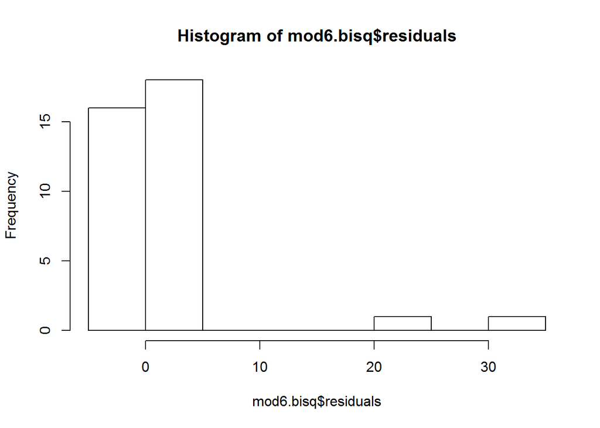

```r
hist(mod6.bisq$residuals)
```

```r
# Test de heterocedasticidad
bptest (mod6.bisq, data=oecd)
```

```
##
##  studentized Breusch-Pagan test
##
## data:  mod6.bisq
## BP = 1.1379, df = 1, p-value = 0.2861
```

```r
shapiro.test(mod6.esth$residuals) # p-value < 0.05   rechezamos la hipotesis nula de la distribucion normal de residuos
```

```
##
##  Shapiro-Wilk normality test
##
## data:  mod6.esth$residuals
## W = 0.46967, p-value = 2.936e-10
```

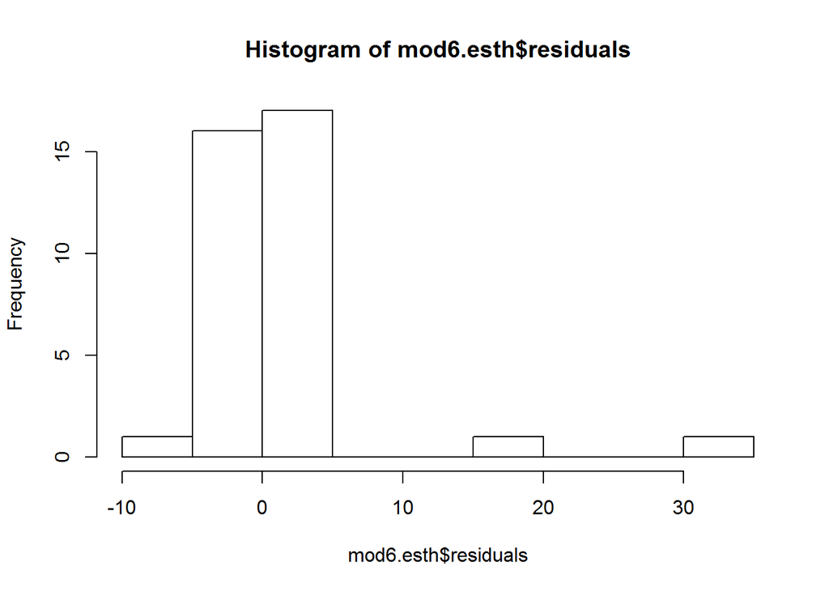

```r
hist(mod6.esth$residuals)
```

```r
bptest (mod6.esth, data=oecd)
```

```
##
##  studentized Breusch-Pagan test
##
## data:  mod6.esth
## BP = 1.1379, df = 1, p-value = 0.2861
```

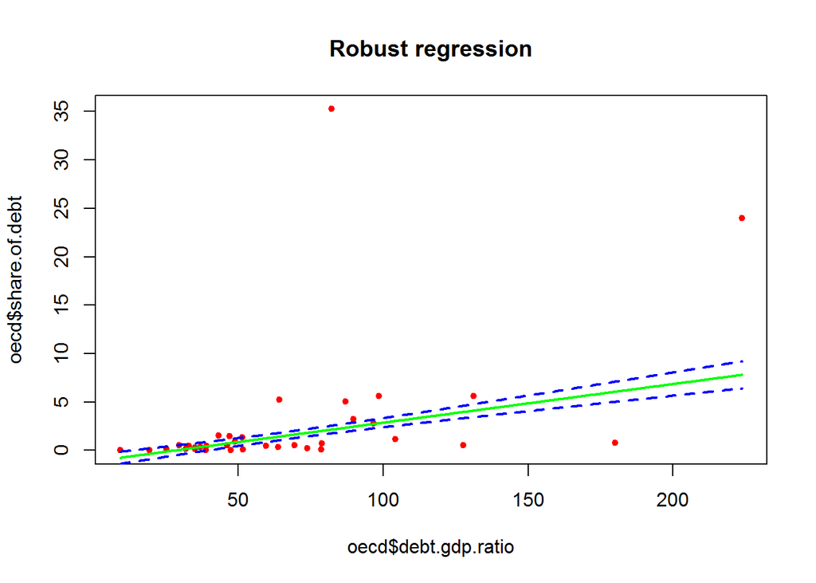

```r
#Valores predichos
#Una vez ajustado el modelo, generamos un conjunto de puntos nuevo para poder predecir nuevos valores regresados
rang <- range(oecd$debt.gdp.ratio)
npuntos <- seq(from = rang[1], to = rang[2], by = 0.5)
npuntos <- data.frame(debt.gdp.ratio = npuntos)
npredic  <- predict(mod6.esth, newdata = npuntos, se.fit = TRUE, level = 0.95)

intconf <- data.frame(
                  inferior = npredic$fit - 1.96*npredic$se.fit,
                  superior = npredic$fit + 1.96*npredic$se.fit)
#Y finalmente se dibujan los puntos originales con los puntos predichos y el intervalo de confianza.
plot(x = oecd$debt.gdp.ratio, y =oecd$share.of.debt, pch = 20, col = "red")
title("Robust regression")
lines(x = npuntos$debt.gdp.ratio, npredic$fit, col = "green", lwd = 2)
lines(x = npuntos$debt.gdp.ratio, intconf$inferior, col = "blue",
      lwd = 2, lty = 2)
lines(x = npuntos$debt.gdp.ratio, intconf$superior, col = "blue",
      lwd = 2, lty = 2)
```

```r
# la predicción que daría el modelo logaritmico para un país que lograra una tasa de deuda sobre el PIB del 25%.
new1=data.frame(debt.gdp.ratio =log(25))
# 95% confidence
pred = predict(mod2, newdata=new1, interval = "prediction", level = 0.95)
exp(pred)
```

```
##          fit          lwr        upr
## 1 0.00149912 4.290594e-05 0.05237879
```